# practice8

team8

7/6/2021

```r
prsa <- read.csv('data/PRSA_data.csv')
library(dplyr)
library(tidyr)
library(stringr)
library(lubridate)
```

```r
library(ROCR)
library(ggplot2)
library(rpart)
```

#### Q1. 미세먼지 예보 기준에 따르면 PM2.5가 75(ug/mˆ3)를 초과할 때, “매우 나쁨”이 된다. 미세먼지가 매우 나쁨을 의미하는 bad_air column을 추가하자.

bad_air 변수의 값은 TRUE/FLASE이다.  
이 때, PM2.5에 NA 존재하는 행은 삭제한다.  
2010년부터 2013년까지의 데이터를 학습 데이터(train data), 2014년데이터를 테스트 데이터로 설정하자.

#### **code**

```r
str(prsa)
```

```
## 'data.frame':    43824 obs. of  13 variables:
##  $ No   : int  1 2 3 4 5 6 7 8 9 10 ...
##  $ year : int  2010 2010 2010 2010 2010 2010 2010 2010 2010 2010 ...
##  $ month: int  1 1 1 1 1 1 1 1 1 1 ...
##  $ day  : int  1 1 1 1 1 1 1 1 1 1 ...
##  $ hour : int  0 1 2 3 4 5 6 7 8 9 ...
##  $ pm2.5: int  NA NA NA NA NA NA NA NA NA NA ...
##  $ DEWP : int  -21 -21 -21 -21 -20 -19 -19 -19 -19 -20 ...
##  $ TEMP : num  -11 -12 -11 -14 -12 -10 -9 -9 -9 -8 ...
##  $ PRES : num  1021 1020 1019 1019 1018 ...
##  $ cbwd : chr  "NW" "NW" "NW" "NW" ...
##  $ Iws  : num  1.79 4.92 6.71 9.84 12.97 ...
##  $ Is   : int  0 0 0 0 0 0 0 0 0 0 ...
##  $ Ir   : int  0 0 0 0 0 0 0 0 0 0 ...
```

```r
glimpse(prsa)
```

```
## Rows: 43,824
## Columns: 13
## $ No    <int> 1, 2, 3, 4, 5, 6, 7, 8, 9, 10, 11, 12, 13, 14, 15, 16, 17, 18, 1…
## $ year  <int> 2010, 2010, 2010, 2010, 2010, 2010, 2010, 2010, 2010, 2010, 2010…
## $ month <int> 1, 1, 1, 1, 1, 1, 1, 1, 1, 1, 1, 1, 1, 1, 1, 1, 1, 1, 1, 1, 1, 1…
## $ day   <int> 1, 1, 1, 1, 1, 1, 1, 1, 1, 1, 1, 1, 1, 1, 1, 1, 1, 1, 1, 1, 1, 1…
## $ hour  <int> 0, 1, 2, 3, 4, 5, 6, 7, 8, 9, 10, 11, 12, 13, 14, 15, 16, 17, 18…
## $ pm2.5 <int> NA, NA, NA, NA, NA, NA, NA, NA, NA, NA, NA, NA, NA, NA, NA, NA, …
## $ DEWP  <int> -21, -21, -21, -21, -20, -19, -19, -19, -19, -20, -19, -18, -19,…
## $ TEMP  <dbl> -11, -12, -11, -14, -12, -10, -9, -9, -9, -8, -7, -5, -5, -3, -2…
## $ PRES  <dbl> 1021, 1020, 1019, 1019, 1018, 1017, 1017, 1017, 1017, 1017, 1017…
## $ cbwd  <chr> "NW", "NW", "NW", "NW", "NW", "NW", "NW", "NW", "NW", "NW", "NW"…
## $ Iws   <dbl> 1.79, 4.92, 6.71, 9.84, 12.97, 16.10, 19.23, 21.02, 24.15, 27.28…
## $ Is    <int> 0, 0, 0, 0, 0, 0, 0, 0, 0, 0, 0, 0, 0, 0, 0, 0, 0, 0, 0, 0, 0, 0…
## $ Ir    <int> 0, 0, 0, 0, 0, 0, 0, 0, 0, 0, 0, 0, 0, 0, 0, 0, 0, 0, 0, 0, 0, 0…
```

```r
#remove column
prsa <-prsa[,-1]
sum(is.na(prsa))
```

```
## [1] 2067
```

```r
colSums(is.na(prsa))
```

```
##  year month   day  hour pm2.5  DEWP  TEMP  PRES  cbwd   Iws    Is    Ir
##     0     0     0     0  2067     0     0     0     0     0     0     0
```

```r
prsa <- na.omit(prsa)
prsa$bad_air <- ifelse(prsa$pm2.5>75, TRUE, FALSE)

prsa$cbwd <- as.factor(prsa$cbwd)
levels(prsa$cbwd)
```

```
## [1] "cv" "NE" "NW" "SE"
```

```r
##divide into train data and test data
train_data<-subset(prsa, prsa$year<2014)
test_data <- subset(prsa, prsa$year==2014)

## number of sample agter delete NA
num_train <-nrow(train_data)
num_test <-nrow(test_data)

## rate after delete NA
round(prop.table(table(prsa$year<2014))*100,2)
```

```
##
## FALSE  TRUE
## 20.74 79.26
```

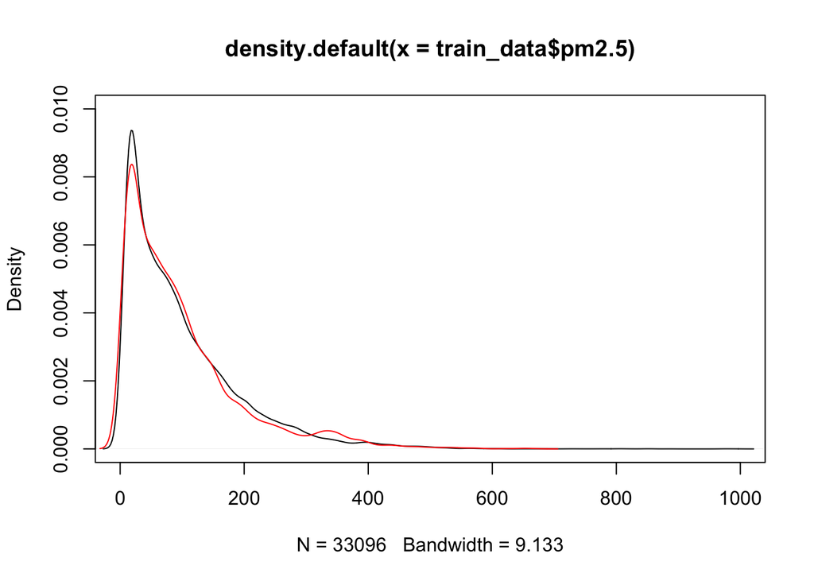

```r
#draw graph
plot(density(train_data$pm2.5),xlim = c(0,1000), ylim=c(0,0.01))
par(new = TRUE)
lines(density(test_data$pm2.5), col="red")
```

```r
var(train_data$bad_air)
```

```
## [1] 0.2498118
```

```r
var(test_data$bad_air)
```

```
## [1] 0.2496458
```

#### Q2. 학습데이터를 사용하여 미세먼지 나쁨여부(bad_air)를 예측하는 decision tree model(Best Model)을 만드시오.

학습데이터에서 사용가능한 모든 변수를 입력변수로 사용하여 미세먼지 나쁨여부(bad_air) 예측 decision tree 를 학습하시오.  
학습에 사용가능한 변수와 사용할 수 없는 (혹은 사용하면 안되는) 변수가 있다면 무엇인지 설명하고, 제외하여 모델을 학습하시오.

#### **code**

```r
pm_model <- rpart(bad_air ~ month+day+hour+DEWP+TEMP+PRES+cbwd+Iws+Ir+Is, data=train_data, method="class", control= rpart.control(cp=0))


library(rpart.plot)
#rpart.plot(pm_model)
```

#### **Solution**

- overfitting이다. pm_model의 경우 year와 pm2.5를 제외하고 모두 입렵변수로 할당했다.  
  목적변수가 pm2.5의 높고 낮음을 기준으로 하는 bad_air이기 때문에 입력변수로써 pm2.5를 사용할 수 없다.  
  year의 경우에는 년도에 따라 미세먼지의 수치가 바뀐다고 할 수 없으므로 사용할 수 없다.

#### Q3. 문제 2에서 학습한 모델의 Accuracy, Precision, Recall, F1 값을 계산하여보라.

Train data와 Test data 둘다에 대해서 계산한 후 비교하여보라. 이 모델은 과적합인가 이유와 함께 설명하여라.

#### **code**

```r
##for train data
train_data$pred <- predict(pm_model, train_data, type = 'class')
conf.table <- table(train_data$bad_air, train_data$pred)
accuracy1<-mean(train_data$bad_air == train_data$pred)

##for test data
test_data$pred <-predict(pm_model, test_data, type='class')
conf.table.t<-table(test_data$bad_air, test_data$pred)
accuracy1.t <- mean(test_data$bad_air == test_data$pred)

##recall
recall <- conf.table[2,2]/sum(conf.table[,2])
recall.t <-conf.table.t[2,2]/sum(conf.table.t[,2])

precision <- conf.table[2,2]/ sum(conf.table[2,])
precision.t <- conf.table[2,2]/ sum(conf.table[2,])
##F1

F1.train <- 2 * precision * recall / (precision + recall)

train_data <-train_data[-14]
test_data <-test_data[-14]
```

#### **Solution**

- predict 함수를 사용하여 pm_model에 train_data 값을 넣어 예측한 값을 train_data에 ‘pred’라는 새로운 열로 만들었다.  
  conf.table은 bad_air를 예상한 것과 실제 bad_air인지를 나타낸 table이다.  
  mean 함수를 사용하여 bad_air와 pred가 일치할 때를 구하였다.  
  이 값은 accuracy로 train_data의 경우 0.8925248이, test_data의 경우 0.7275141이 도출되었는데 test_data의 accuracy가 train_data 보다 작으니 overfitting됐다고 할 수 있다.  
  precision은 bad_air가 TRUE로 나올 확률값을 나타내고 recall은 실제 bad_air가 FALSE로 나온 값의 비율이다.

train_data의 precision은 0.8887162, recall은 0.8899888이고, test_data의 precision은 0.7428503, recall은 0.7055467임을 알 수 있다.  
F1.train의 값은 0.889352, F1.test의 값은 0.7237181로 종합적으로 봤을 때 accuracy, precision, recall, F1 값 모두 test_data가 train_data에 비해 작음을 알 수 있고 이는 과적합된 상태임을 나타낸다.

#### Q4. pre-pruning 방식을 사용하여 과적합을 해소한 모델을 학습하여보라.

새롭게 학습한 모델의 Accuracy, Precision, Recall, F1 값을 계산하여보라.  
과적합이 얼마나 해소되었는지, 성능은 어떻게 변화하였는지 설명하여라

#### **code**

```r
# pm_model <- rpart(bad_air ~ month+day+hour+DEWP+TEMP+PRES+cbwd+Iws+Ir+Is, data=train_data, method="class", control= rpart.control(cp=0, minsplit = 50))
pm_model <- rpart(bad_air ~ month+day+hour+DEWP+TEMP+PRES+cbwd+Iws+Ir+Is, data=train_data, method="class", control= rpart.control(cp=0, minsplit = 100))
# pm_model <- rpart(bad_air ~ month+day+hour+DEWP+TEMP+PRES+cbwd+Iws+Ir+Is, data=train_data, method="class", control= rpart.control(cp=0, minsplit = 200))
# pm_model <- rpart(bad_air ~ month+day+hour+DEWP+TEMP+PRES+cbwd+Iws+Ir+Is, data=train_data, method="class", control= rpart.control(cp=0, minsplit = 300))


##for train data
train_data$pred <- predict(pm_model, train_data, type = 'class')
conf.table <- table(train_data$bad_air, train_data$pred)
accuracy2 <-mean(train_data$bad_air == train_data$pred)
##for test data
test_data$pred <-predict(pm_model, test_data, type='class')
conf.table.t<-table(test_data$bad_air, test_data$pred)
accuracy2.t <- mean(test_data$bad_air == test_data$pred)
accuracy2- accuracy2.t
```

```
## [1] 0.07467901
```

```r
##recall
recall_pre <- conf.table[2,2]/sum(conf.table[,2])
recall.t_pre <-conf.table.t[2,2]/sum(conf.table.t[,2])

precision_pre <- conf.table[2,2]/ sum(conf.table[2,])
precision.t_pre <- conf.table[2,2]/ sum(conf.table[2,])

##F1

F1.train_pre <- 2 * precision_pre * recall_pre / (precision_pre + recall_pre)
F1.t.train_pre <- 2 * precision.t_pre * recall.t_pre / (precision.t_pre + recall.t_pre)

train_data <-train_data[-14]
test_data <-test_data[-14]
```

#### **Solution**

- pre-pruning 방식에는 max depth와 minsplit을 활용하는 방안이 존재한다.  
  minsplit이 50일 경우 train_accuracy가 0.8465978, 100일 경우 0.8218214, 200일 경우 0.800701, 300일 경우 0.7916667이고, 50일 경우 test_accuracy가 0.7522226, 100일 경우 0.7471424, 200일 경우 0.732248, 300일 경우 0.7449486가 나온다.  
  accuracy가 높고 train_accuracy와 test_accuracy의 차이가 적게 나는 100을 기준점으로 선택하였다.

max depth가 5일 경우 accuracy가 0.6665512, 8일 경우 0.7273987, 10일 경우 0.751068, 12일 경우 0.7436786로 max depth가 10일 경우 accuracy가 가장 크기 때문에 10을 선택했다.

#### Q5. post-pruning 방식을 사용하여 과적합을 해소한 모델을 학습하여보라.

새롭게 학습한 모델의 Accuracy, Precision, Recall, F1 값을 계산하여보라. 과적합이 얼마나 해소되었는지, 성능은 어떻게 변화하였는지 설명하여라

#### **code**

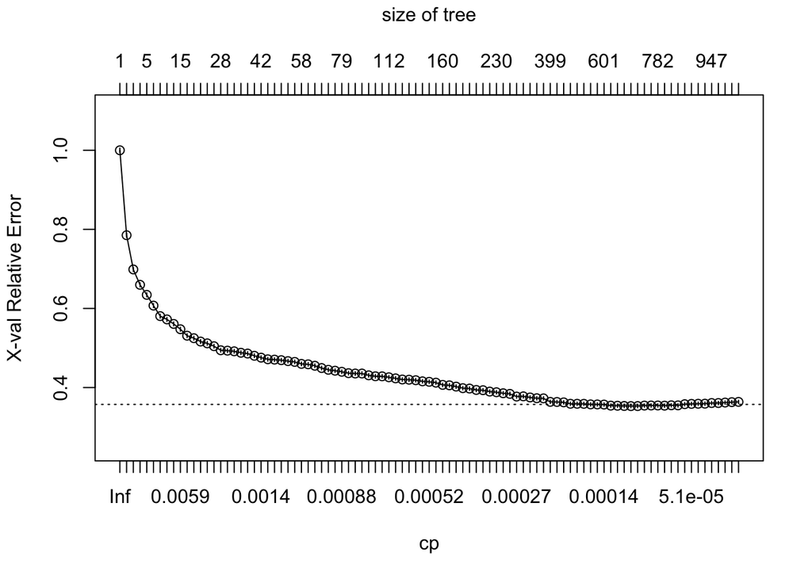

```r
 # prune → cp = 0.00045 , test accuracy : 0.7549936
 # prune → cp = 0.00014 , test accuracy : 0.7434476
 # prune → cp = 0.00024 , test accuracy : 0.7530308
 # prune → cp = 0.00041 , test accuracy : 0.7561483
 # prune → cp = 0.00023 , test accuracy : 0.7585729

pm_model <- rpart(bad_air ~ month+day+hour+DEWP+TEMP+PRES+cbwd+Iws+Ir+Is, data=train_data, method="class", control= rpart.control(cp=0))

plotcp(pm_model)
```

```r
##0.00035

pm_model_pruned <- prune(pm_model, cp=0.00045)

##for train data
train_data$pred <- predict(pm_model_pruned, train_data, type = 'class')
conf.table <- table(train_data$bad_air, train_data$pred)
accuracy3 <-mean(train_data$bad_air == train_data$pred)

##for test data
test_data$pred <-predict(pm_model_pruned, test_data, type='class')
conf.table.t<-table(test_data$bad_air, test_data$pred)
accuracy3.t <- mean(test_data$bad_air == test_data$pred)
accuracy3 - accuracy3.t
```

```
## [1] 0.07267968
```

```r
##recall
recall_post <- conf.table[2,2]/sum(conf.table[,2])
recall.t_post <-conf.table.t[2,2]/sum(conf.table.t[,2])

precision_post <- conf.table[2,2]/ sum(conf.table[2,])
precision.t_post <- conf.table.t[2,2]/ sum(conf.table.t[2,])

##F1

F1.train_post <- 2 * precision_post * recall_post / (precision_post + recall_post)
F1.t.train_post <- 2 * precision.t_post * recall.t_post / (precision.t_post + recall.t_post)
```

#### **Solution**

- post-pruning 방식을 쓰기 위해 우선 plotcp 함수를 써서 변화를 확인하였다. 그리고 변화율이 적은 cp값들을 몇가지 뽑아서 측정해 그 중에서 제일 accurancy가 괜찮고, overfitting이 적은 값으로 측정하였다. cp가 0.00045일 때 제일 overfitting이 작아 cp값으로 하고 측정한 결과 train data에서와 test 데이터에서의 차이가 0.07267968 발생하였다.

[output not shown]

위의 결과를 봤을 때 pre-pruning과 비교했을 때 F1는 높아졌으나, overfitting은 감소하였다. pre-pruning에서는 overfitting이 0.07467901, post-pruning에서는 overfitting이 0.07267968이었다. pre-pruning에서 accuracy는 train과 test에서 각각 0.8218214, 0.7471424였다. test data의 경우 post-pruning이 accuracy가 더 높다. post-pruning과 비교했을 때 F1의 경우 pre-pruning과 post-pruning에서 train data의 경우, 0.8179433, 0.8246197이고, test data에서 pre-pruning은 0.7695633, post-pruning은 0.7778981로 높아졌다. F1이 높아지고, post-pruning에서 overfitting이 감소하였기에 성능이 좋아졌다고 볼 수 있다.

#### Q6. 설명력이 높은 변수를 추가하거나, 중복되거나 의미없는 변수를 제거하는 과정을 feature engineering이라고 한다.

이러한 과정을 통해서 모델의 성능을 개선할 수 있다.  
입력변수의 조정을 통해서 성능이 더 높은 모델을 학습하여보라. (이 때, 문제 4,5에서 적용했던 pruning 방식을 함께 적용해도 됨)

#### **code**

```r
##
summary(train_data)
```

```
##       year          month             day             hour
##  Min.   :2010   Min.   : 1.000   Min.   : 1.00   Min.   : 0.0
##  1st Qu.:2011   1st Qu.: 4.000   1st Qu.: 8.00   1st Qu.: 5.0
##  Median :2012   Median : 7.000   Median :16.00   Median :12.0
##  Mean   :2012   Mean   : 6.516   Mean   :15.67   Mean   :11.5
##  3rd Qu.:2013   3rd Qu.:10.000   3rd Qu.:23.00   3rd Qu.:18.0
##  Max.   :2013   Max.   :12.000   Max.   :31.00   Max.   :23.0
##      pm2.5             DEWP              TEMP             PRES      cbwd
##  Min.   :  0.00   Min.   :-33.000   Min.   :-19.00   Min.   : 991   cv: 6888
##  1st Qu.: 29.00   1st Qu.:-11.000   1st Qu.:  1.00   1st Qu.:1008   NE: 3763
##  Median : 73.00   Median :  1.000   Median : 13.00   Median :1016   NW:11058
##  Mean   : 98.84   Mean   :  1.666   Mean   : 12.06   Mean   :1016   SE:11387
##  3rd Qu.:138.00   3rd Qu.: 15.000   3rd Qu.: 23.00   3rd Qu.:1025
##  Max.   :994.00   Max.   : 28.000   Max.   : 41.00   Max.   :1046
##       Iws               Is                 Ir           bad_air
##  Min.   :  0.45   Min.   : 0.00000   Min.   : 0.0000   Mode :logical
##  1st Qu.:  1.79   1st Qu.: 0.00000   1st Qu.: 0.0000   FALSE:17011
##  Median :  5.81   Median : 0.00000   Median : 0.0000   TRUE :16085
##  Mean   : 25.02   Mean   : 0.06085   Mean   : 0.2112
##  3rd Qu.: 23.26   3rd Qu.: 0.00000   3rd Qu.: 0.0000
##  Max.   :565.49   Max.   :27.00000   Max.   :36.0000
##     pred
##  FALSE:16378
##  TRUE :16718
##
##
##
##
```

```r
##delete day, Is, Ir
pm_model <- rpart(bad_air ~ month+DEWP+TEMP+cbwd, data=train_data, method="class", control= rpart.control(cp=0,maxdepth = 10))
#pruned
pm_model_pruned2 <- prune(pm_model, cp = 0.00045)


##for train data
train_data$pred <- predict(pm_model_pruned2, train_data, type = 'class')
conf.table <- table(train_data$bad_air, train_data$pred)
accuracy4 <-mean(train_data$bad_air == train_data$pred)
##for test data
test_data$pred <-predict(pm_model_pruned2, test_data, type='class')
conf.table.t<-table(test_data$bad_air, test_data$pred)
accuracy4.t <- mean(test_data$bad_air == test_data$pred)

##recall
recall_post2 <- conf.table[2,2]/sum(conf.table[,2])
recall.t_post2 <-conf.table.t[2,2]/sum(conf.table.t[,2])

precision_post2 <- conf.table[2,2]/ sum(conf.table[2,])
precision.t_post2 <- conf.table[2,2]/ sum(conf.table[2,])

##F1

F1.train_post2 <- 2 * precision_post2 * recall_post2 / (precision_post2 + recall_post2)
F1.t.train_post2 <- 2 * precision.t_post2 * recall.t_post2 / (precision.t_post2 + recall.t_post2)
```

#### Q7. 문제 2에서 6까지 얻은 모델 중 가장 성능이 높은 모델을 선정하여. ROC커브를 그리고 AUC를 계산하시오.

- Train 데이터, Test 데이터 모두에 대해서
- Hint, decision tree model의 predict 명령에서 type = ‘prob’를 하면 확률 값을 얻을 수 있습니다.

#### **code**

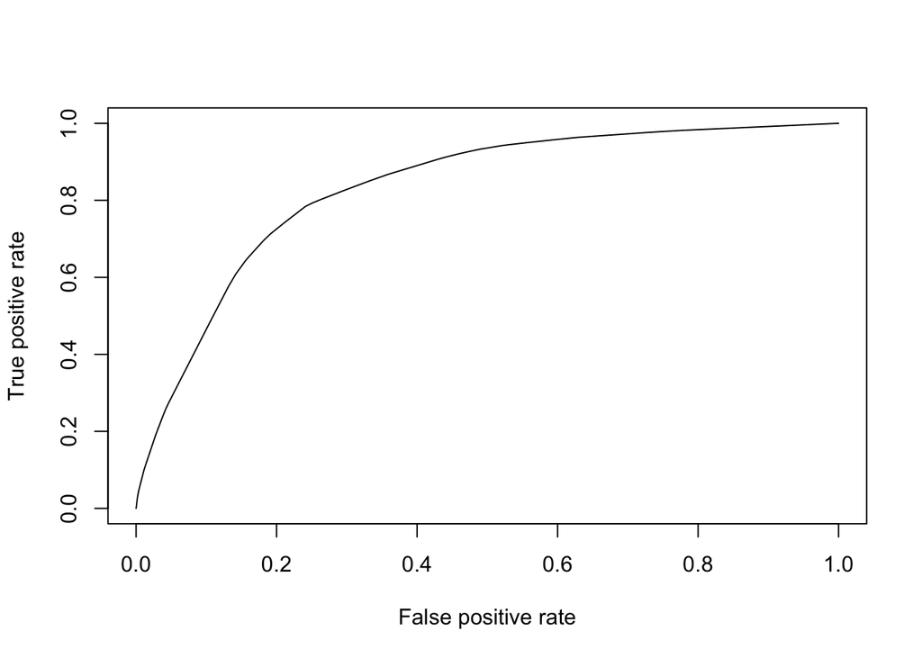

```r
##for train data
train_data$pred_prob <- predict(pm_model_pruned2, train_data, type = 'prob')

pred <- prediction(train_data$pred_prob[, 2], train_data$bad_air)
plot(performance(pred, 'tpr', 'fpr'))
```

```r
AUC_train <- performance(pred, 'auc')
as.numeric(AUC_train@y.values)
```

```
## [1] 0.8326873
```

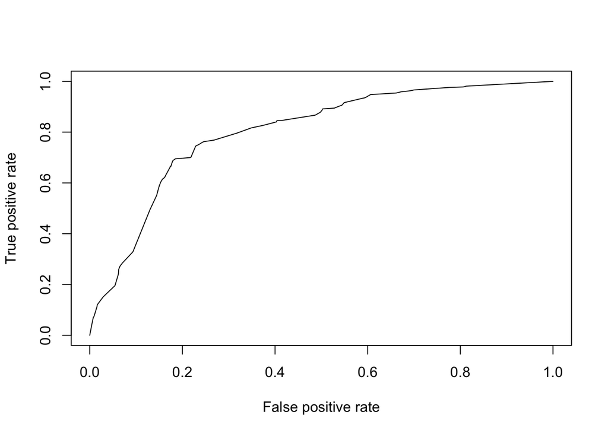

```r
test_data$pred_prob <- predict(pm_model_pruned2, test_data, type = 'prob')
pred_test <- prediction(test_data$pred_prob[, 2], test_data$bad_air)
plot(performance(pred_test, 'tpr', 'fpr'))
```

```r
AUC_test <- performance(pred_test, 'auc')
as.numeric(AUC_test@y.values)
```

```
## [1] 0.8010294
```

#### **Solution**

- predict에서 type을 ‘prob’로 해서 확률값을 받아서 이를 train과 test에 대한 ROC curve로 그렸다. train에서 AUC 값은 0.8326873, test에서 AUC 값은 0.8010294였다. Finding best model 자료에 의하면 .80 ~.90은 good model이라고 볼 수 있기에 위에서 사용한 model은 좋은 model이라고 판단할 수 있다.

#### Q8.문제 7에서 선정한 모델에서 threshold를 0에서 1까지 변경할 때, Accuracy, Precision, Recall, F1 값의 변화를 확인하여라. threshold를 얼마로 선정하는 것이 가장 적절할 것인지 판단하여 설명하여라.

- 모델의 예측 결과에 따라 우리는 미세먼지 농도를 “매우 나쁨”으로 예보하거나 “매우 나쁨은 아님”으 로 예보하게 된다고 하자. False Positive와 False Negative의 비용에 대해서 생각해보고, 이런 맥락에서 Precision과 Recall을 어떤 수준으로 조정해야하는지, 그에 따른 threshold를 생각해보자.

#### **code**

```r
# train_data$pred_prob <- train_data$pred_prob[,2]
# threshold <- 0.4
# train_data$prediction <- train_data$pred_prob >threshold

train_data$est.prop <- train_data$pred_prob[,2]
threshold <- 0.5
train_data$prediction <- train_data$est.prop > threshold
conf.table <- table(pred = train_data$prediction, actual = train_data$bad_air)
# conf.table
accuracy <- sum(diag(conf.table))  / sum(conf.table)
# accuracy

#test
test_data$est.prop <- test_data$pred_prob[,2]
threshold <- 0.5
test_data$prediction <- test_data$est.prop > threshold
conf.table.t <- table(pred = test_data$prediction, actual = test_data$bad_air)
# conf.table.t
accuracy.t <- sum(diag(conf.table.t))  / sum(conf.table.t)
# accuracy.t
precision <- conf.table[2,2] / sum(conf.table[ 2, ])
recall <- conf.table[2,2] / sum(conf.table[ , 2])
precision.t <- conf.table.t[2,2] / sum(conf.table.t[ 2, ])
recall.t <- conf.table.t[2,2] / sum(conf.table.t[ , 2])
F1.train <- 2* precision*recall / (precision + recall)
F1.test <- 2* precision.t*recall.t / (precision.t + recall.t)
# print(paste("accuracy on training set", round(accuracy, 2)))
# print(paste("accuracy on testing set", round(accuracy.t, 2)))
# print(c(precision,recall,precision.t,recall.t,F1.train,F1.test))

#0.1
threshold1 <- 0.1
train_data$prediction <- train_data$est.prop > threshold1
conf.table1 <- table(pred = train_data$prediction, actual = train_data$bad_air)
test_data$prediction <- test_data$est.prop > threshold1
conf.table.t1 <- table(pred = test_data$prediction, actual = test_data$bad_air)
precision1 <- conf.table1[2,2] / sum(conf.table1[ 2, ])
recall1 <- conf.table1[2,2] / sum(conf.table1[ , 2])
precision.t1 <- conf.table.t1[2,2] / sum(conf.table.t1[ 2, ])
recall.t1 <- conf.table.t1[2,2] / sum(conf.table.t1[ , 2])
F1.train1 <- 2* precision1*recall1 / (precision1 + recall1)
F1.test1 <- 2* precision.t1*recall.t1 / (precision.t1 + recall.t1)

accuracy1 <- sum(diag(conf.table1))  / sum(conf.table1)
accuracy.t1 <- sum(diag(conf.table.t1))  / sum(conf.table.t1)
# print(paste("accuracy on training set", round(accuracy1, 2)))
# print(paste("accuracy on testing set", round(accuracy.t1, 2)))
# print(c(precision1,recall1,precision.t1,recall.t1,F1.train1,F1.test1))

#0.2
threshold2 <- 0.2
train_data$prediction <- train_data$est.prop > threshold2
conf.table2 <- table(pred = train_data$prediction, actual = train_data$bad_air)
test_data$prediction <- test_data$est.prop > threshold2
conf.table.t2 <- table(pred = test_data$prediction, actual = test_data$bad_air)
precision2 <- conf.table2[2,2] / sum(conf.table2[ 2, ])
recall2 <- conf.table2[2,2] / sum(conf.table2[ , 2])
precision.t2 <- conf.table.t2[2,2] / sum(conf.table.t2[ 2, ])
recall.t2 <- conf.table.t2[2,2] / sum(conf.table.t2[ , 2])
F1.train2 <- 2* precision2*recall2 / (precision2 + recall2)
F1.test2 <- 2* precision.t2*recall.t2 / (precision.t2 + recall.t2)

accuracy2 <- sum(diag(conf.table2))  / sum(conf.table2)
# accuracy2
accuracy.t2 <- sum(diag(conf.table.t2))  / sum(conf.table.t2)
# accuracy.t2
# print(paste("accuracy on training set", round(accuracy2, 2)))
# print(paste("accuracy on testing set", round(accuracy.t2, 2)))
# print(c(precision2,recall2,precision.t2,recall.t2,F1.train2,F1.test2))

#0.3
threshold3 <- 0.3
train_data$prediction <- train_data$est.prop > threshold3
conf.table3 <- table(pred = train_data$prediction, actual = train_data$bad_air)
test_data$prediction <- test_data$est.prop > threshold3
conf.table.t3 <- table(pred = test_data$prediction, actual = test_data$bad_air)
precision3 <- conf.table3[2,2] / sum(conf.table3[ 2, ])
recall3 <- conf.table3[2,2] / sum(conf.table3[ , 2])
precision.t3 <- conf.table.t3[2,2] / sum(conf.table.t3[ 2, ])
recall.t3 <- conf.table.t3[2,2] / sum(conf.table.t3[ , 2])
F1.train3 <- 2* precision3*recall3 / (precision3 + recall3)
F1.test3 <- 2* precision.t3*recall.t3 / (precision.t3 + recall.t3)

accuracy3 <- sum(diag(conf.table3))  / sum(conf.table3)
# accuracy3
accuracy.t3 <- sum(diag(conf.table.t3))  / sum(conf.table.t3)
# accuracy.t3
# print(paste("accuracy on training set", round(accuracy3, 2)))
# print(paste("accuracy on testing set", round(accuracy.t3, 2)))
# print(c(precision3,recall3,precision.t3,recall.t3,F1.train3,F1.test3))

#0.4
threshold4 <- 0.9
train_data$prediction <- train_data$est.prop > threshold4
conf.table4 <- table(pred = train_data$prediction, actual = train_data$bad_air)
test_data$prediction <- test_data$est.prop > threshold4
conf.table.t4 <- table(pred = test_data$prediction, actual = test_data$bad_air)
precision4 <- conf.table4[2,2] / sum(conf.table4[ 2, ])
recall4 <- conf.table4[2,2] / sum(conf.table4[ , 2])
precision.t4 <- conf.table.t4[2,2] / sum(conf.table.t4[ 2, ])
recall.t4 <- conf.table.t4[2,2] / sum(conf.table.t4[ , 2])
F1.train4 <- 2* precision4*recall4 / (precision4 + recall4)
F1.test4 <- 2* precision.t4*recall.t4 / (precision.t4 + recall.t4)

accuracy4 <- sum(diag(conf.table4))  / sum(conf.table4)
# accuracy4
accuracy.t4 <- sum(diag(conf.table.t4))  / sum(conf.table.t4)
# accuracy.t4
# print(paste("accuracy on training set", round(accuracy4, 2)))
# print(paste("accuracy on testing set", round(accuracy.t4, 2)))
# print(c(precision4,recall4,precision.t4,recall.t4,F1.train4,F1.test4))
```

#### **Solution**

[output not shown]